# Hierarchical Cluster

Niharika Pillanagoyala

24/04/2021

Setting up working directory

```r
setwd("C:/Users/nihar/Desktop/Assignment/ML/HC")
set.seed(123)
```

Importing required library.

```r
library(cluster)
library(caret)
library(dendextend)
library(knitr)
library(factoextra)
```

# Data Importing

### cereals dataset

```r
library(readr)
cereals<-read.csv("Cereals.csv")

DataFrame <- data.frame(cereals[,4:16])
```

# Data Pre-Processing

To remove any missing value that might be present in the data.

```r
OmitMissing <- na.omit(DataFrame)
```

# Data Normalization

### Data Scaling

Normalizing the Data using Scale function.

```r
Normalise <- scale(OmitMissing)
```

### Using the euclidean distance to measure the distance

Computing the dissimilarity matrix values by using Dist and the method is Euclidean.

```r
d <- dist(Normalise, method = "euclidean")
```

Perform Hierarchical Clustering using complete linkage.

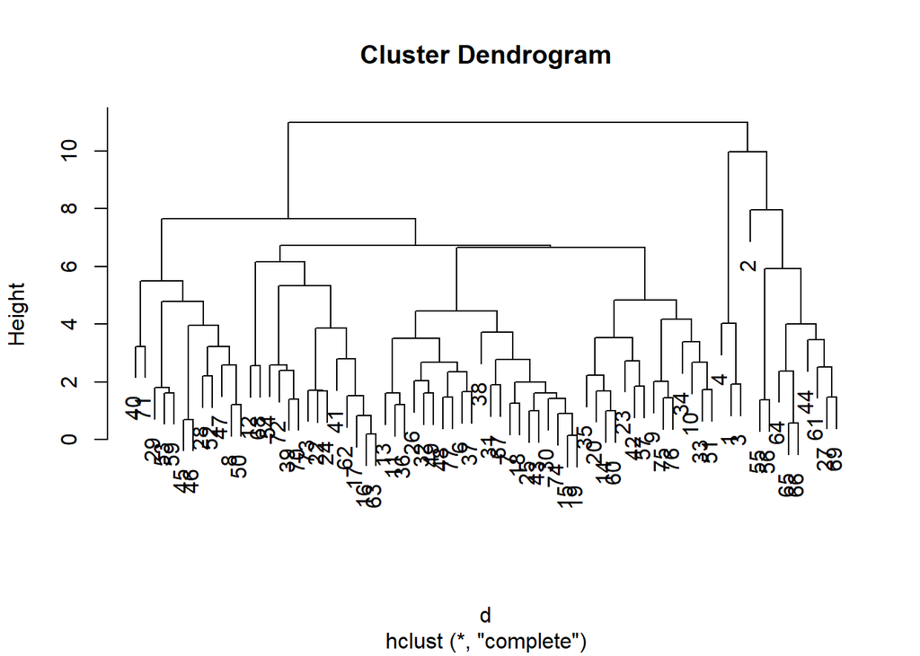

```r
HC <- hclust(d, method = "complete")
plot(HC)
```

Plotting the dendogram.

```r
round(HC$height, 3)
```

```
##  [1]  0.143  0.196  0.575  0.698  0.828  0.904  1.003  1.004  1.201  1.203
## [11]  1.254  1.378  1.408  1.421  1.454  1.463  1.474  1.517  1.608  1.611
## [21]  1.616  1.625  1.650  1.687  1.692  1.720  1.730  1.795  1.839  1.897
## [31]  1.919  1.982  2.015  2.046  2.203  2.224  2.339  2.381  2.394  2.522
## [41]  2.563  2.574  2.579  2.668  2.682  2.734  2.776  2.787  3.229  3.236
## [51]  3.385  3.451  3.510  3.535  3.717  3.866  3.957  4.005  4.031  4.168
## [61]  4.456  4.779  4.839  5.342  5.488  5.920  6.169  6.669  6.731  7.650
## [71]  7.964  9.979 10.984
```

### Determining Optimal Clusters

Highliting the clusters directly in dendogram

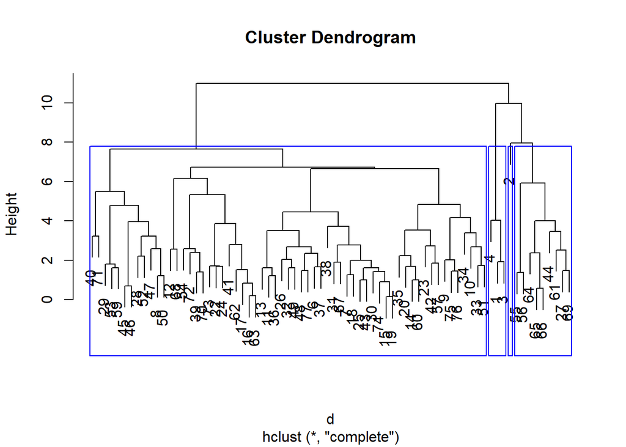

```r
plot(HC)
rect.hclust(HC,
  k = 4, # k is used to specify the number of clusters
  border = "Blue"
)
```

> > We can also use agnes() function to perform clustering. Performing clustering using agnes() with single, complete, average and ward.

```r
HCsingle <- agnes(Normalise, method = "single")
HCcomplete <- agnes(Normalise, method = "complete")
HCaverage <- agnes(Normalise, method = "average")
HCward <- agnes(Normalise, method = "ward")
```

Now we will compare the agglomerative coefficients,for Single,complete, average and ward.

```r
print(HCsingle$ac)
```

```
## [1] 0.6067859
```

```r
print(HCcomplete$ac)
```

```
## [1] 0.8353712
```

```r
print(HCaverage$ac)
```

```
## [1] 0.7766075
```

```r
print(HCward$ac)
```

```
## [1] 0.9046042
```

> > The results says that the wards method is the best with the value of 0.904. Plotting the agnes using ward method and Cutting the Dendrogram. We will take k = 4 by observing the distance.

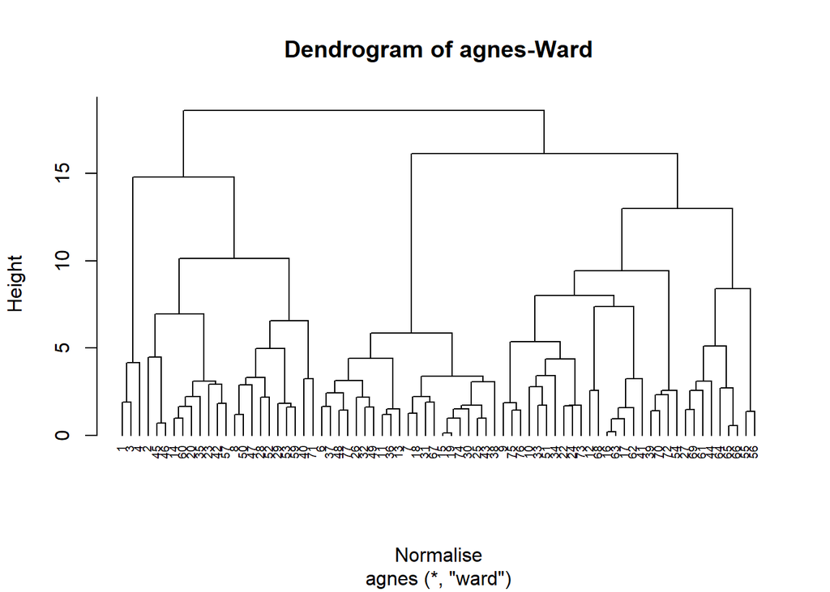

```r
pltree(HCward, cex = 0.6, hang = -1, main = "Dendrogram of agnes-Ward")
```

> > Hierarchical clustering using ward method.

```r
HC1 <- hclust(d, method = "ward.D2" )
subgrp <- cutree(HC1, k = 4)
table(subgrp)
```

```
## subgrp
##  1  2  3  4
##  3 20 21 30
```

```r
dataframe <- as.data.frame(cbind(Normalise,subgrp))
```

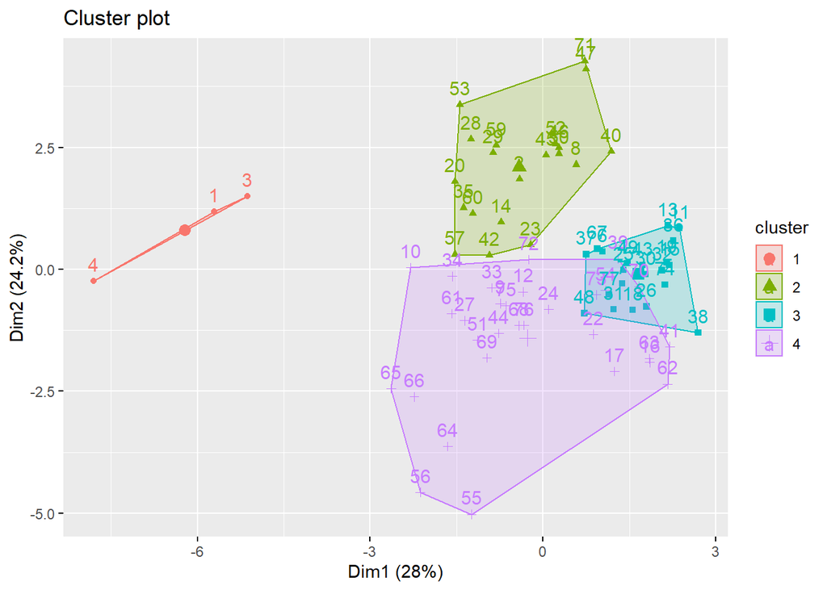

```r
fviz_cluster(list(data = Normalise, cluster = subgrp))
```

> > To check the structure of the clusters and on their stability. We will partition the data and apply one part to the other part

```r
Datapart1 <- OmitMissing[1:50,]
Datapart2 <- OmitMissing[51:74,]
```

Performing Hierarichal Clustering using agnes() with single, complete, average and ward with partitioned data , plotting dendrogram and then cutting the dendrogram by taking k = 4.

```r
Award <- agnes(scale(Datapart1), method = "ward")
Aaverage <- agnes(scale(Datapart1), method = "average")
Acomplete <- agnes(scale(Datapart1), method = "complete")
Asingle <- agnes(scale(Datapart1), method = "single")
cbind(ward=Award$ac, average=Aaverage$ac, complete=Acomplete$ac,
      single=Asingle$ac)
```

```
##           ward   average  complete    single
## [1,] 0.8764323 0.7408904 0.8138238 0.6393338
```

> > Plot dendogram for the partitioned data.

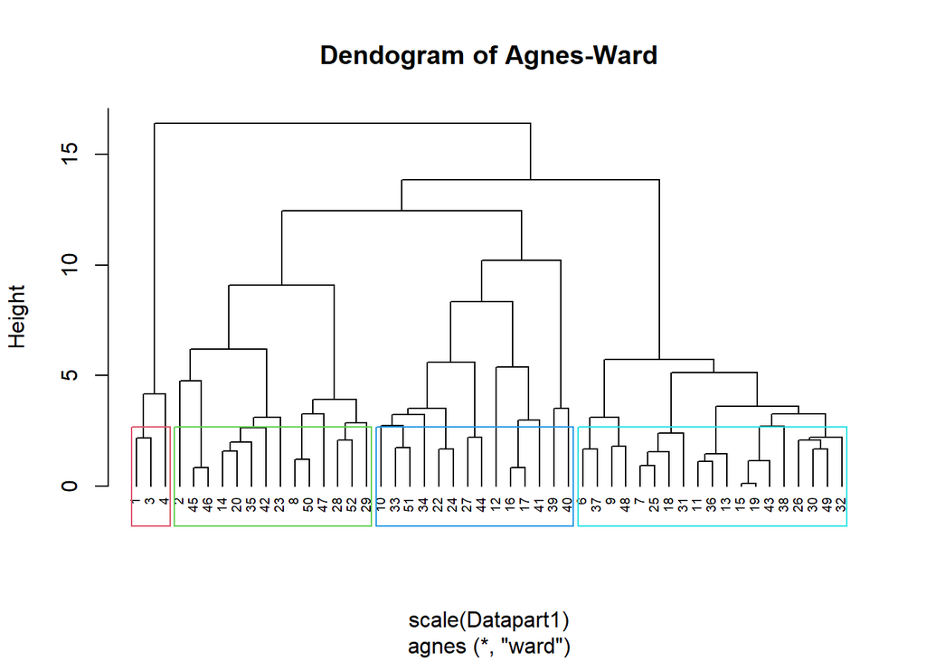

```r
pltree(Award, cex = 0.6, hang = -1, main = "Dendogram of Agnes-Ward")
rect.hclust(Award, k = 4, border = 2:5)
```

using Cuttres to divide into groups cluster = 4.

```r
c <- cutree(Award, k = 4)
print(c)
```

```
##  1  2  3  4  6  7  8  9 10 11 12 13 14 15 16 17 18 19 20 22 23 24 25 26 27 28
##  1  2  1  1  3  3  2  3  4  3  4  3  2  3  4  4  3  3  2  4  2  4  3  3  4  2
## 29 30 31 32 33 34 35 36 37 38 39 40 41 42 43 44 45 46 47 48 49 50 51 52
##  2  3  3  3  4  4  2  3  3  3  4  4  4  2  3  4  2  2  2  3  3  2  4  2
```

Calculating centers to assess the consistent of data.

```r
Assess <- as.data.frame(cbind(Datapart1,c))

Assess[Assess$c==1,]
```

```
##   calories protein fat sodium fiber carbo sugars potass vitamins shelf weight
## 1       70       4   1    130    10     5      6    280       25     3      1
## 3       70       4   1    260     9     7      5    320       25     3      1
## 4       50       4   0    140    14     8      0    330       25     3      1
##   cups   rating c
## 1 0.33 68.40297 1
## 3 0.33 59.42551 1
## 4 0.50 93.70491 1
```

```r
c1 <- colMeans(Assess[Assess$c==1,])
Assess[Assess$c==2,]
```

```
##    calories protein fat sodium fiber carbo sugars potass vitamins shelf weight
## 2       120       3   5     15   2.0   8.0      8    135        0     3   1.00
## 8       130       3   2    210   2.0  18.0      8    100       25     3   1.33
## 14      110       3   2    140   2.0  13.0      7    105       25     3   1.00
## 20      110       3   3    140   4.0  10.0      7    160       25     3   1.00
## 23      100       2   1    140   2.0  11.0     10    120       25     3   1.00
## 28      120       3   2    160   5.0  12.0     10    200       25     3   1.25
## 29      120       3   0    240   5.0  14.0     12    190       25     3   1.33
## 35      120       3   3     75   3.0  13.0      4    100       25     3   1.00
## 42      100       4   2    150   2.0  12.0      6     95       25     2   1.00
## 45      150       4   3     95   3.0  16.0     11    170       25     3   1.00
## 46      150       4   3    150   3.0  16.0     11    170       25     3   1.00
## 47      160       3   2    150   3.0  17.0     13    160       25     3   1.50
## 50      140       3   2    220   3.0  21.0      7    130       25     3   1.33
## 52      130       3   2    170   1.5  13.5     10    120       25     3   1.25
##    cups   rating c
## 2  1.00 33.98368 2
## 8  0.75 37.03856 2
## 14 0.50 40.40021 2
## 20 0.50 40.44877 2
## 23 0.75 36.17620 2
## 28 0.67 40.91705 2
## 29 0.67 41.01549 2
## 35 0.33 45.81172 2
## 42 0.67 45.32807 2
## 45 1.00 37.13686 2
## 46 1.00 34.13976 2
## 47 0.67 30.31335 2
## 50 0.67 40.69232 2
## 52 0.50 30.45084 2
```

```r
c2 <- colMeans(Assess[Assess$c==2,])
Assess[Assess$c==3,]
```

```
##    calories protein fat sodium fiber carbo sugars potass vitamins shelf weight
## 6       110       2   2    180   1.5  10.5     10     70       25     1      1
## 7       110       2   0    125   1.0  11.0     14     30       25     2      1
## 9        90       2   1    200   4.0  15.0      6    125       25     1      1
## 11      120       1   2    220   0.0  12.0     12     35       25     2      1
## 13      120       1   3    210   0.0  13.0      9     45       25     2      1
## 15      110       1   1    180   0.0  12.0     13     55       25     2      1
## 18      110       1   0     90   1.0  13.0     12     20       25     2      1
## 19      110       1   1    180   0.0  12.0     13     65       25     2      1
## 25      110       2   1    125   1.0  11.0     13     30       25     2      1
## 26      110       1   0    200   1.0  14.0     11     25       25     1      1
## 30      110       1   1    135   0.0  13.0     12     25       25     2      1
## 31      100       2   0     45   0.0  11.0     15     40       25     1      1
## 32      110       1   1    280   0.0  15.0      9     45       25     2      1
## 36      120       1   2    220   1.0  12.0     11     45       25     2      1
```

[output cut: 25 more lines]

```r
c3 <- colMeans(Assess[Assess$c==3,])
Assess[Assess$c==4,]
```

```
##    calories protein fat sodium fiber carbo sugars potass vitamins shelf weight
## 10       90       3   0    210     5    13      5    190       25     3    1.0
## 12      110       6   2    290     2    17      1    105       25     1    1.0
## 16      110       2   0    280     0    22      3     25       25     1    1.0
## 17      100       2   0    290     1    21      2     35       25     1    1.0
## 22      110       2   0    220     1    21      3     30       25     3    1.0
## 24      100       2   0    190     1    18      5     80       25     3    1.0
## 27      100       3   0      0     3    14      7    100       25     2    1.0
## 33      100       3   1    140     3    15      5     85       25     3    1.0
## 34      110       3   0    170     3    17      3     90       25     3    1.0
## 39      110       2   1    170     1    17      6     60      100     3    1.0
## 40      140       3   1    170     2    20      9     95      100     3    1.3
## 41      110       2   1    260     0    21      3     40       25     2    1.0
## 44      100       4   1      0     0    16      3     95       25     2    1.0
## 51       90       3   0    170     3    18      2     90       25     3    1.0
##    cups   rating c
## 10 0.67 53.31381 4
## 12 1.25 50.76500 4
## 16 1.00 41.44502 4
## 17 1.00 45.86332 4
## 22 1.00 46.89564 4
## 24 0.75 44.33086 4
## 27 0.80 58.34514 4
## 33 0.88 52.07690 4
## 34 0.25 53.37101 4
## 39 1.00 36.52368 4
## 40 0.75 36.47151 4
## 41 1.50 39.24111 4
## 44 1.00 54.85092 4
## 51 1.00 59.64284 4
```

```r
c4 <- colMeans(Assess[Assess$c==4,])
```

Binding the 4 centers.

```r
centers <- rbind(c1,c2,c3,c4)
centers
```

```
##     calories  protein       fat   sodium      fiber     carbo    sugars
## c1  63.33333 4.000000 0.6666667 176.6667 11.0000000  6.666667  3.666667
## c2 125.71429 3.142857 2.2857143 146.7857  2.8928571 13.892857  8.857143
## c3 110.00000 1.526316 1.0000000 179.4737  0.7368421 12.736842 10.947368
## c4 105.71429 2.857143 0.5000000 182.8571  1.7857143 17.857143  4.071429
##       potass vitamins    shelf   weight      cups   rating c
## c1 310.00000 25.00000 3.000000 1.000000 0.3866667 73.84446 1
## c2 139.64286 23.21429 2.928571 1.142143 0.6914286 38.13235 2
## c3  50.78947 25.00000 1.631579 1.000000 0.8842105 29.46119 3
## c4  80.00000 35.71429 2.357143 1.021429 0.9178571 48.08120 4
```

Calculating Distance and comparing the record in B with the closest centroid in A

```r
d1 <- as.data.frame(rbind(centers[,-14],Datapart2))
d2 <- get_dist(d1)
matrix <- as.matrix(d2)
df1 <- data.frame(data=seq(1,nrow(Datapart2),1),clusters=rep(0,nrow(Datapart2)))

for(i in 1:nrow(Datapart2)) {

  df1[i,2] <- which.min(matrix[i+4, 1:4])
}

df1
```

```
##    data clusters
## 1     1        1
## 2     2        4
## 3     3        3
## 4     4        2
## 5     5        2
## 6     6        1
## 7     7        2
## 8     8        2
## 9     9        3
## 10   10        3
## 11   11        2
## 12   12        2
## 13   13        2
## 14   14        3
## 15   15        4
## 16   16        2
## 17   17        3
## 18   18        2
## 19   19        4
## 20   20        4
## 21   21        3
## 22   22        4
## 23   23        4
## 24   24        3
```

```r
cbind(dataframe$subgrp[51:74], df1$clusters)
```

```
##       [,1] [,2]
##  [1,]    2    1
##  [2,]    4    4
##  [3,]    4    3
##  [4,]    4    2
##  [5,]    2    2
##  [6,]    2    1
##  [7,]    2    2
##  [8,]    4    2
##  [9,]    4    3
## [10,]    4    3
## [11,]    4    2
## [12,]    4    2
## [13,]    4    2
## [14,]    3    3
## [15,]    4    4
## [16,]    4    2
## [17,]    4    3
## [18,]    2    2
## [19,]    4    4
## [20,]    4    4
## [21,]    3    3
## [22,]    4    4
## [23,]    4    4
## [24,]    3    3
```

```r
table(dataframe$subgrp[51:74] == df1$clusters)
```

```
##
## FALSE  TRUE
##    12    12
```

### Selecting the cluster that is best cereal for breakfast, which will have high protein, fiber and low in sugar, sodium.

Choosing the Cluster of Healthy Cereals.

```r
newdata <- cereals
newdata_omit <- na.omit(newdata)

Clust <- cbind(newdata_omit, subgrp)

Clust[Clust$subgrp==1,]
```

```
##                        name mfr type calories protein fat sodium fiber carbo
## 1                 100%_Bran   N    C       70       4   1    130    10     5
## 3                  All-Bran   K    C       70       4   1    260     9     7
## 4 All-Bran_with_Extra_Fiber   K    C       50       4   0    140    14     8
##   sugars potass vitamins shelf weight cups   rating subgrp
## 1      6    280       25     3      1 0.33 68.40297      1
## 3      5    320       25     3      1 0.33 59.42551      1
## 4      0    330       25     3      1 0.50 93.70491      1
```

```r
Clust[Clust$subgrp==2,]
```

```
##                                      name mfr type calories protein fat sodium
## 2                       100%_Natural_Bran   Q    C      120       3   5     15
## 8                                 Basic_4   G    C      130       3   2    210
## 14                               Clusters   G    C      110       3   2    140
## 20                     Cracklin'_Oat_Bran   K    C      110       3   3    140
## 23                 Crispy_Wheat_&_Raisins   G    C      100       2   1    140
## 28 Fruit_&_Fibre_Dates,_Walnuts,_and_Oats   P    C      120       3   2    160
## 29                          Fruitful_Bran   K    C      120       3   0    240
## 35                     Great_Grains_Pecan   P    C      120       3   3     75
## 40                 Just_Right_Fruit_&_Nut   K    C      140       3   1    170
## 42                                   Life   Q    C      100       4   2    150
## 45       Muesli_Raisins,_Dates,_&_Almonds   R    C      150       4   3     95
## 46      Muesli_Raisins,_Peaches,_&_Pecans   R    C      150       4   3    150
## 47                   Mueslix_Crispy_Blend   K    C      160       3   2    150
## 50              Nutri-Grain_Almond-Raisin   K    C      140       3   2    220
```

[output cut: 27 more lines]

```r
Clust[Clust$subgrp==3,]
```

```
##                       name mfr type calories protein fat sodium fiber carbo
## 6  Apple_Cinnamon_Cheerios   G    C      110       2   2    180   1.5  10.5
## 7              Apple_Jacks   K    C      110       2   0    125   1.0  11.0
## 11            Cap'n'Crunch   Q    C      120       1   2    220   0.0  12.0
## 13   Cinnamon_Toast_Crunch   G    C      120       1   3    210   0.0  13.0
## 15             Cocoa_Puffs   G    C      110       1   1    180   0.0  12.0
## 18               Corn_Pops   K    C      110       1   0     90   1.0  13.0
## 19           Count_Chocula   G    C      110       1   1    180   0.0  12.0
## 25             Froot_Loops   K    C      110       2   1    125   1.0  11.0
## 26          Frosted_Flakes   K    C      110       1   0    200   1.0  14.0
## 30          Fruity_Pebbles   P    C      110       1   1    135   0.0  13.0
## 31            Golden_Crisp   P    C      100       2   0     45   0.0  11.0
## 32          Golden_Grahams   G    C      110       1   1    280   0.0  15.0
## 36        Honey_Graham_Ohs   Q    C      120       1   2    220   1.0  12.0
## 37      Honey_Nut_Cheerios   G    C      110       3   1    250   1.5  11.5
```

[output cut: 29 more lines]

```r
Clust[Clust$subgrp==4,]
```

```
##                           name mfr type calories protein fat sodium fiber carbo
## 9                    Bran_Chex   R    C       90       2   1    200     4    15
## 10                 Bran_Flakes   P    C       90       3   0    210     5    13
## 12                    Cheerios   G    C      110       6   2    290     2    17
## 16                   Corn_Chex   R    C      110       2   0    280     0    22
## 17                 Corn_Flakes   K    C      100       2   0    290     1    21
## 22                     Crispix   K    C      110       2   0    220     1    21
## 24                 Double_Chex   R    C      100       2   0    190     1    18
## 27         Frosted_Mini-Wheats   K    C      100       3   0      0     3    14
## 33           Grape_Nuts_Flakes   P    C      100       3   1    140     3    15
## 34                  Grape-Nuts   P    C      110       3   0    170     3    17
## 39 Just_Right_Crunchy__Nuggets   K    C      110       2   1    170     1    17
## 41                         Kix   G    C      110       2   1    260     0    21
## 44                       Maypo   A    H      100       4   1      0     0    16
## 51           Nutri-grain_Wheat   K    C       90       3   0    170     3    18
```

[output cut: 47 more lines]

Calculating mean ratings to determine the best cluster.

```r
mean(Clust[Clust$subgrp==1,"rating"])
```

```
## [1] 73.84446
```

```r
mean(Clust[Clust$subgrp==2,"rating"])
```

```
## [1] 38.26161
```

```r
mean(Clust[Clust$subgrp==3,"rating"])
```

```
## [1] 28.84825
```

```r
mean(Clust[Clust$subgrp==4,"rating"])
```

```
## [1] 51.43111
```

> > As we can see that the mean ratings for the subgrp==1 is the highest its 73.84. So its a best option to choose cluster 1 and the cereals in the cluster 1 for healthy diet. We should eliminate the cereals with low nutrition.